# What the Proxy Predictor Set Can Deliver

Out-of-sample accuracy for micronutrient deficiency prediction across four African countries

Author

Andrew N. Mertens, University of California, Berkeley

Published

August 31, 2026

## Summary

Four national biomarker surveys, **294 harmonised proxy predictors**, **554 districts**, **24 country–outcome combinations**. Every interval below is a bootstrap or design-based confidence interval on out-of-sample performance — nothing here is an in-sample fit.

| **24/24** | predicted national prevalences fall inside the survey’s own 95% CI |
| --- | --- |
| **0.96 pp** | mean absolute error on national prevalence |
| **2.31×** | best targeting lift; above 1.0× in 22 of 24 combinations |
| **7/15** | district rankings transport to a country the model never saw |

## National prevalence recovery

The strongest result in the programme, and the one that has survived every change to the pipeline.

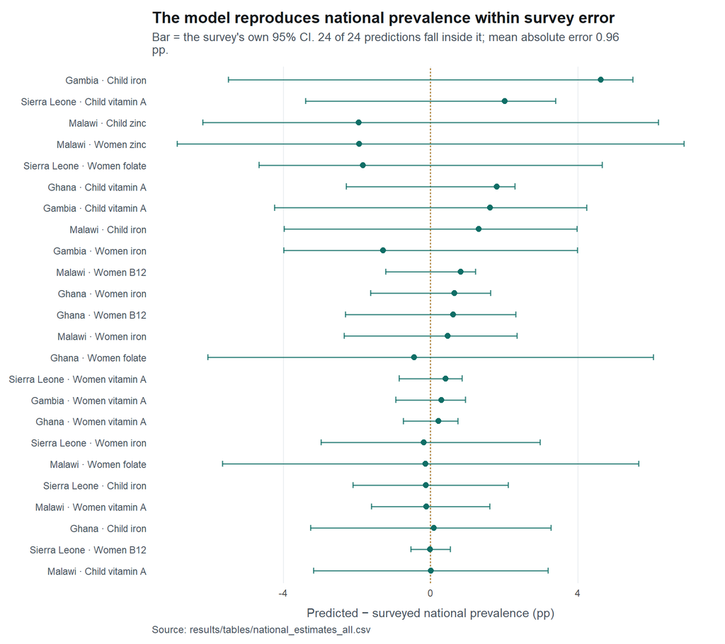

Figure 1

## Targeting value

If a programme could reach only the top 20% of districts, how many more true deficiency cases would the model’s ranking find than no targeting?

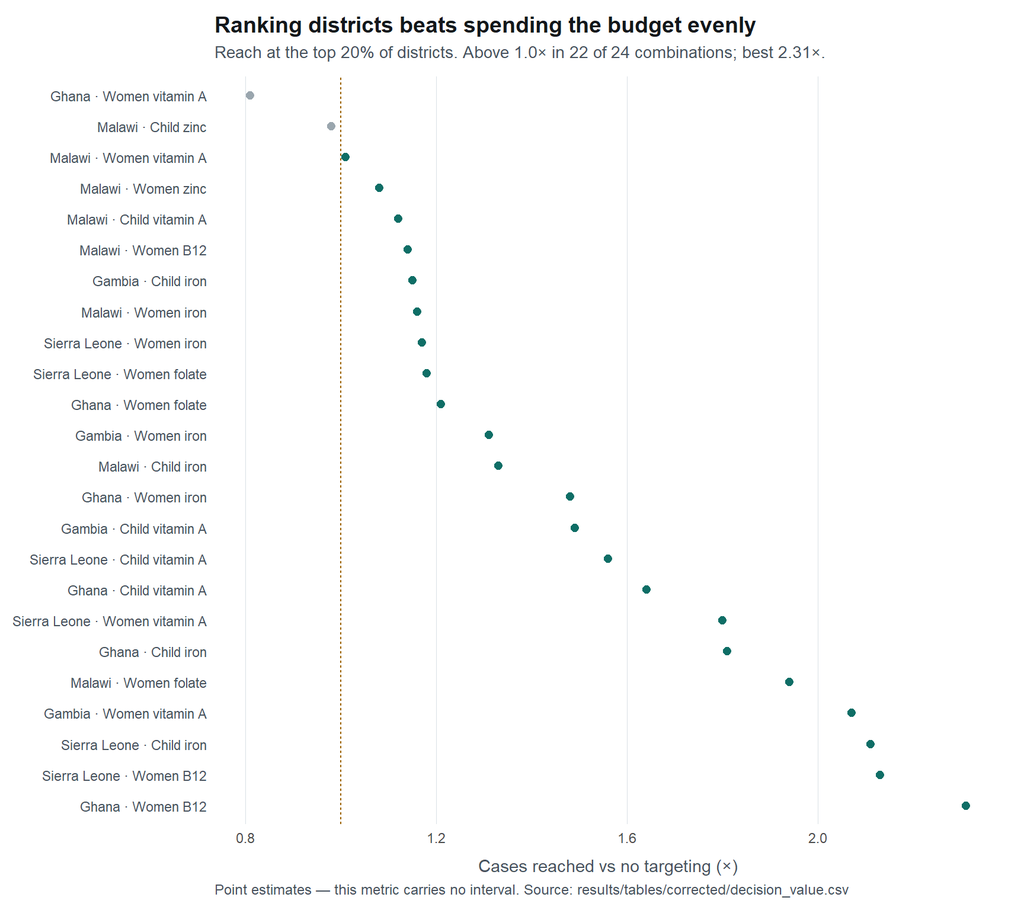

Figure 2

## Transport to an unseen country

The hardest test: train on three countries, predict district prevalence in a fourth using no biomarker data from it.

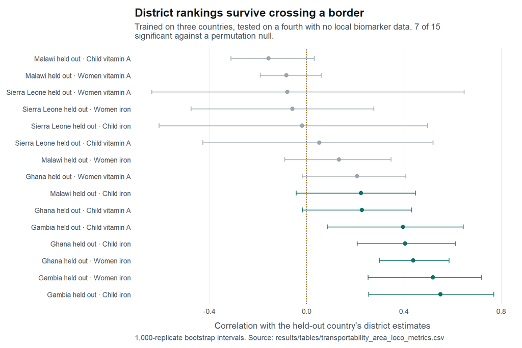

Figure 3

## Within-country district ranking

The most demanding resolution, and the results are correspondingly mixed.

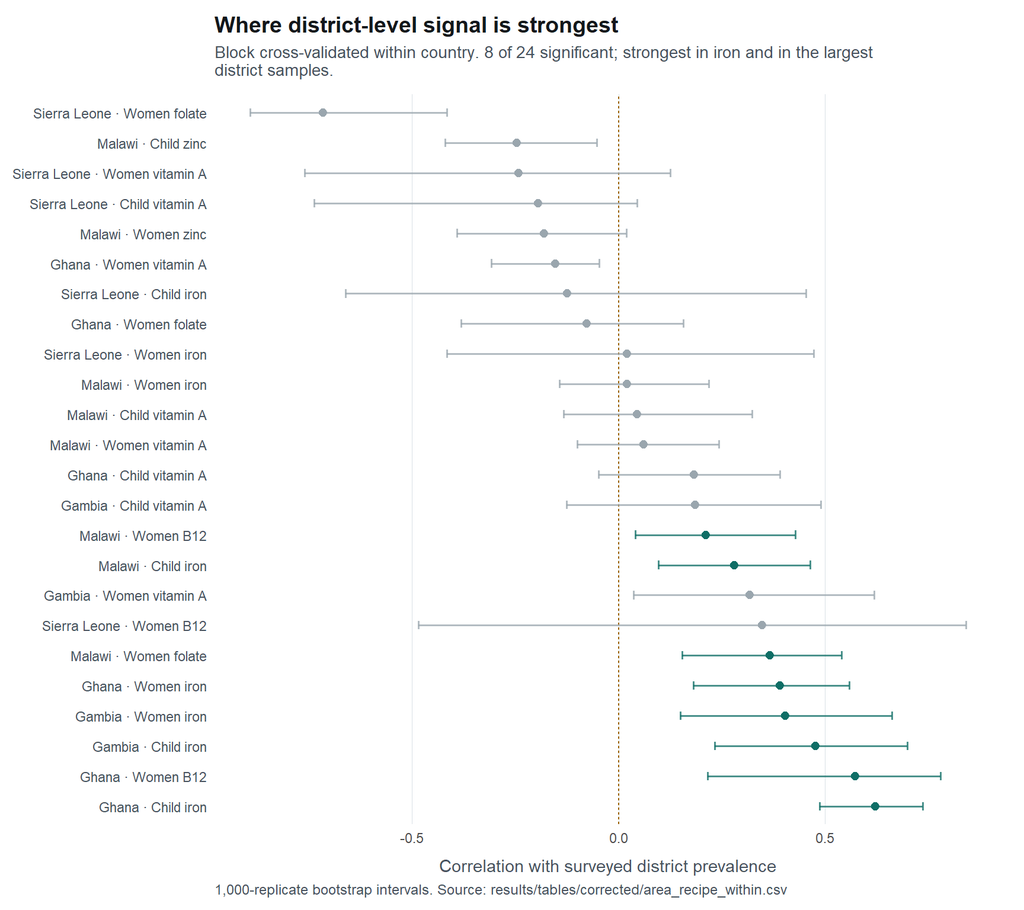

Figure 4

## The design choice that pays

| Approach | Cells | Mean r | MAE (pp) | Mean \|bias\| (pp) |
| --- | --- | --- | --- | --- |
| District model anchored to regional totals | 24 | 0.406 | 8.86 | 1.49 |
| District model, shrunken regional anchor | 24 | 0.306 | 9.38 | 2.41 |
| Fit at region, extrapolated to district | 22 | 0.244 | 8.87 | 3.42 |
| District model anchored to national total | 24 | 0.176 | 11.77 | 5.47 |
| District model alone, no anchor | 24 | 0.170 | 10.40 | 3.60 |

## What this brief does not claim

**National prevalence is recovered far better than district prevalence.** The national result is the robust one. District maps should be read as rankings rather than as absolute prevalence.

**Absolute levels do not transport across borders even where rankings do**, with national bias reaching 42 pp in the worst case. This is why the anchoring step above matters: it is not a refinement, it is what makes a transported district map interpretable at all.

**Covariate selection inflates apparent accuracy.** Screening predictors on all data before cross-validating adds a mean of **+0.18** to the rank correlation, positive in 20 of 20 measurable cells and up to +0.51 — enough to turn cells with zero real skill into respectable-looking ones. All figures in this brief screen inside the cross-validation fold.

**At district level the model does not beat a national average on risk classification.** Assigning each district to a WHO public-health category (None / Mild / Moderate / Severe) for child vitamin A, the covariate model is correct 33% of the time against **32% for giving every district the national prevalence**. At region level the same comparison is 56% against 35%. This is the clearest statement of where the proxy set does and does not earn its place, and it is why the hybrid design — regions where a country has enough of them, districts otherwise — is our recommended product.

Table 1: All approaches. MRP and the SL rows are scored IN-SAMPLE and are not comparable with the out-of-fold (OOF) rows; the labels say which.

| Approach | Cells | Mean r | MAE (pp) |
| --- | --- | --- | --- |
| MRP | 14 | 0.784 | 5.84 |
| Individual SL | 20 | 0.410 | 11.10 |
| Area wSL, prescreen on ALL data (OPTIMISTIC) | 20 | 0.369 | 11.38 |
| Spatial only (no covariates) | 15 | 0.304 | 12.66 |
| Area wSL, prescreen in-fold (OOF) | 20 | 0.187 | 11.99 |
| Area wSL, literature covariates (OOF) | 20 | 0.147 | 11.97 |
| Area wSL, precision-weighted (OOF) | 20 | 0.145 | 11.74 |
| Area SL (MSE) | 20 | 0.124 | 10.92 |
| Area SL (NLL) | 20 | 0.122 | 11.68 |
| Area wSL, unweighted (OOF) | 20 | 0.096 | 11.65 |

*Proxy modelling for vitamin and mineral deficiencies — Ghana, Sierra Leone, Malawi, The Gambia. With funding support from the Gates Foundation. All intervals are out-of-sample: 1,000-replicate bootstrap for correlations, design-based for survey prevalence.*